# Workout 1

Bolong Zheng

## 1) Introduction

> - This report summarizes the shooting statistics of the five Golden State Warrior players: Iguodala, Green, urant, Thompson
> - We introduce these five players with images and short descriptions.

[figure not shown]

| Description | Value |
| --- | --- |
| Name | Andre Iguodala |
| Position | SG/SF |
| Born | IL, 1984 |
| Height | 6 ft 6 in |

[figure not shown]

| Description | Value |
| --- | --- |
| Name | Draymond Green |
| Position | PF |
| Born | MI, 1990 |
| Height | 6 ft 7 in |

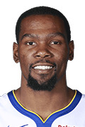

| Description | Value |
| --- | --- |
| Name | Kevin Durant |
| Position | SF |
| Born | D.C., 1988 |
| Height | 6 ft 9 in |

[figure not shown]

| Description | Value |
| --- | --- |
| Name | Klay Thompson |
| Position | SG |
| Born | CA, 1990 |
| Height | 6 ft 7 in |

[figure not shown]

| Description | Value |
| --- | --- |
| Name | Stephen Curry |
| Position | PG |
| Born | OH, 1988 |
| Height | 6 ft 3 in |

For the narrative part, we intuitively decided to foucus on Draymond Green.

## 2) Data

> - All tables have player name, total shots, made shots.

```
## # A tibble: 5 x 4
##   name           total  made perc_made
##   <fct>          <int> <int>     <dbl>
## 1 Andre Iguodala   210   134     0.638
## 2 Kevin Durant     643   390     0.607
## 3 Stephen Curry    563   304     0.540
## 4 Klay Thompson    640   329     0.514
## 5 Graymond Green   346   171     0.494
```

> - This table shows 2PT Field Goal effective shooting percentage by player.

```
## # A tibble: 5 x 4
##   name           total  made perc_made
##   <fct>          <int> <int>     <dbl>
## 1 Klay Thompson    580   246     0.424
## 2 Stephen Curry    687   280     0.408
## 3 Kevin Durant     272   105     0.386
## 4 Andre Iguodala   161    58     0.360
## 5 Graymond Green   232    74     0.319
```

> - This table shows 3PT Field Goal effective shooting percentage by player.

```
## # A tibble: 5 x 4
##   name           total  made perc_made
##   <fct>          <int> <int>     <dbl>
## 1 Kevin Durant     915   495     0.541
## 2 Andre Iguodala   371   192     0.518
## 3 Klay Thompson   1220   575     0.471
## 4 Stephen Curry   1250   584     0.467
## 5 Graymond Green   578   245     0.424
```

> - This table shows overall Field Goal effective shooting percentage by player.

## 3) Narrative

Draymond Green, the Power Forward of Golden State Warriors, was eclipsed in his shooting performance by his teammate in the season of 2016. Don’t get me wrong. Green is an extraordinary black player, but his shooting skills seem indeed questionable.

If we take a look at “the 2PT Effective Shooting % by Player”, Andre Iguodala, Kevin Durant, Stephen Curry and Klay-Thompson all reached the 50% effectiveness in scoring 2PT shots. Nevertheless, Green finished this season with a meager 49.4% chance of making 2PT shots.The poor capability of Green in shooting “halts the entire offense of the Golden State Warriors as what was once a great opportunity to shoot is now just another pass in the system”, according to a Fansided review, [“Golden State Warriors: How bad has Draymond Green鈥檚 shooting been?.”](https://bluemanhoop.com/2019/01/10/golden-state-warriors-how-bad-has-draymond-greens-shooting-been/)

Of course we can not possibly compare Draymond Green with Klay Thompson, who is one of the best 3PT shooters in NBA, and Stephen Curry, who is frequently considered by fans as one of the greatest 3PT shooters. Notwithstanding the fact that Green is teamed with those great 3PT shooters, his execution of 3PT shootings were not only indecisive but also maladroit. People can potentially argue that it is because other people on the team are too good in terms of 3PT shooting so that Green appears subpar. Still, according to “NBA Player 3-Point Shooting Statistics for PF- 2016-17” on ESPN, Green is the last but one among other players with the same position, with Aaron Gordon, who is a much younger player than Green, being the last. Sadly, Green honestly has a lot of space for improvements as a 3Pt shooter.

All in all Green is obviously incompetent in terms of shooting and this inadequacy of him is obtrusively conspicuous alongside his teammates. Even in 2018, Green’s unsatisfactory shooting performance received a great deal of criticism from NBA analysts. An article from “SB Nation” brought to question [“Should Draymond Green continue shooting threes”](https://www.goldenstateofmind.com/2018/12/22/18152009/warriors-2018-draymond-green-three-point-shooting-rotation)?. Although this article went on a defensive side for Draymond Green, it apparently feels stilted and not buttressed by strong arguments. Another piece from “San Fransisco Chronicle” called [“Why Draymond Green’s shooting woes hurt Warriors more than you might think”](https://www.sfchronicle.com/warriors/article/Why-Draymond-Green-s-shooting-woes-hurt-13492428.php) hints at the insidious harm Green has been bringing to his team. These editorials validate that our analysis of the data coincides with the popular opinion.

I really hope Draymond Green can surprise us with improving shooting skills in the forthcoming seasons.

## 4) Reference

> - Wikipedia
> - Basketball-reference.com